# Modelos para la implementación de monitoreo de homicidios

Felipe González

Diciembre, 2018

# 1 Introducción

En este documento mostramos fundamentos y ejemplos de implementación de un sistema de monitoreo de violencia en México basado en los datos de homicidios a nivel municipal provistos por el Secretariado Ejecutivo del Sistema Nacional de Seguridad Pública ((“Datos Abiertos de Incidencia Delictiva” 2018a)).

**El objetivo es producir un detector de anomalías (datos inusualmente altos en incidencia) de los datos reportados, con el fin de enfocar el análisis a acciones a municipios de interés**. Esos municipios de interés deberán ser identificados por reportes inusualmente altos de incidencia de homicidio, en contraste a aquellos municipios donde los datos reportados tengan variación consistente con la que se ha observado históricamente.

Aunque el interés general es medición de violencia, la decisión de utilizar solamente los datos de homicidios (homicidios más feminicidios según la nueva metodología de la SESNSP) se debe a que otros tipos de crímenes violentos tienden a tener niveles altos de cifra negra – alrededor de 90% o más según la [Encuesta de Victimización del INEGI](https://www.inegi.org.mx/programas/envipe/2018/), mientras que esto sucede en mucho menor grado con homicidios. Otras indicadores de crimen con cifra negra relativamente baja son el robo de automóvil, por ejemplo, pero consideramos que este no necesariamente refleja el interés en medir la violencia que experimenta la población en cada municipio.

# 2 Datos

Usamos los datos de homicidios y feminicidios a nivel municipal provistos por el Secretariado Ejecutivo del Sistema Nacional de Seguridad Pública ((“Datos Abiertos de Incidencia Delictiva” 2018a)). Estos datos son publicados cada mes.

Otra fuente de este tipo de datos son los reportados por INEGI, que se consideran más completos y precisos. Los datos de INEGI, sin embargo, son publicados con retraso de un año, lo que los descalifica para un sistema de monitoreo que pretende evaluar la situación actual de los municipios.

```r
library(tidyverse)
library(lubridate)
library(surveillance)
```

El archivo de datos que utilizamos es preprocesado de los datos crudos según el código de https://github.com/diegovalle/new.crimenmexico, a partir de los datos del Secretariado Ejecutivo del Sistema Nacional de Seguridad Pública.

```r
nm <- read_csv("./data/nm-fuero-comun-municipios.csv", progress = FALSE)
nm <- nm %>% mutate(date = ymd(paste0(date, '-01')))
tipo_homidicio <- c("FEMINICIDIO", "HOMICIDIO")
homicidios <- nm %>% filter(tipo %in% tipo_homidicio) %>%
    select(state_code, state, mun_code, municipio, date, count, population) %>%
    group_by(state_code, state, mun_code, municipio, date) %>%
    summarise(population = first(population), count = sum(count))
```

# 3 Metodología

Consideramos que el enfoque apropiado para constuir monitores de violencia es el adoptado en la epidemiología para detección de brotes de enfermedades infecciosas ((Farrington and Andrews 2003)). La detección temprana de estos brotes en una aspecto importante de sistemas de monitoreo epidemiológicos, y están implementados en muchos países (Farrington and Andrews 2003) con el fin de proveerlos de respuesta epidemiológica oportuna.

Existen varias aproximaciones para los construcción de estos sistemas de detección temprana. Por ejemplo:

- CDC y otros: utilizan media, varianza y utilizan una aproximación normal simple. Algunos modelos simples bayesianos son similares a este método.
- Agencias europeas de monitoreo: método de Farrington y variaciones. Similar al modelo bayesiano, pero con un modelo para la media que puede incluir tendencia y estacionalidad.

En este documento, examinaremos algunos de los que más ampliamente implementados, como algunos métodos bayesianos y el método de Farrington (Meyer, Held, and Höhle 2017). Utilizamos las implementaciones del paquete de R [surveillance](https://cran.r-project.org/web/packages/surveillance/vignettes/surveillance.pdf).

# 4 Métodos de monitoreo: bayesiano simple

Uno de los métodos más simples, de desempeño competitivo ((Yang et al. 2018)) utiliza un enfoque parcialmente bayesiano construido a partir de una regresión Poisson con sobredispersión. Este es un ejemplo típico utilizado en la detección de brotes de *Kryptosporidiose* en Alemania (Höhle 2007):

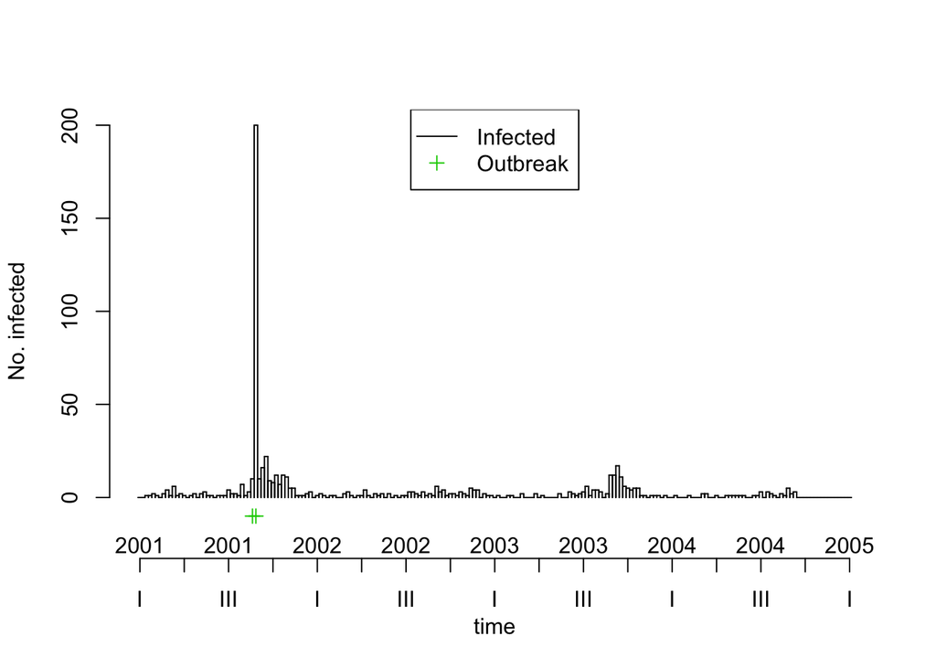

```r
data(k1)
plot(k1)
```

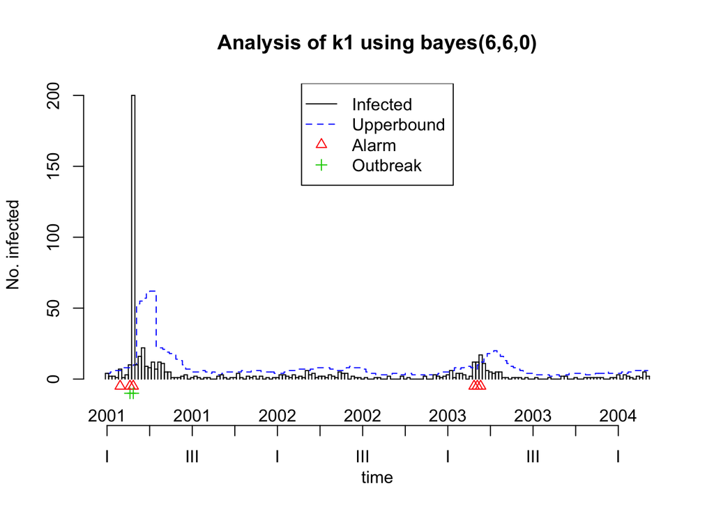

```r
# Evaluar de 27 a 192
k1_surveil <- algo.bayes(k1,
  control = list(range = 27:192, b = 0, w = 6, alpha = 0.01))
plot(k1_surveil)
```

Para aplicar este método, primero definimos:

- Valores de referencia para estimar parámetros del modelo, que son las observaciones pasadas de conteos de homicidios $y_i$.
- Región donde queremos crear predicciones, límites superiores, y detectar anomalías.

Una vez definida la ventana de valores de referencia y horizonte de predicción, el modelo para nuevas observaciones (ver referencia) $y_k$ es

- $P(y_k | \lambda)$ es Poisson con parmátro lambda
- $\lambda$ es Gamma con parámetros $(\alpha, \beta)$.

De forma que la posterior para $\lambda$ es Gamma con parámetros $(\alpha + \sum_i y_i, \beta + n)$, y la posterior predictiva es Poisson-Gamma con los mismos parámetros.

Una vez que calculamos la posterior predictiva, establecemos una alarma si la observación $y_k$ satisface $y_k > y_\alpha$, donde $y_\alpha$ es el cuantil $1- \alpha$ de la posterior predictiva.

### 4.0.1 Ejemplos: método bayesiano.

Consideramos tres municipios de Puebla:

```r
#puebla_edo <- filter(homicidios, state == "PUEBLA")
puebla_edo <- readRDS("data/puebla.rds")
puebla_edo %>% group_by(municipio) %>% summarise(count = sum(count)) %>%
    arrange(desc(count)) %>%
    filter(municipio %in% c("PUEBLA", "CHILCHOTLA", "HUAUCHINANGO"))
```

```
## # A tibble: 3 x 2
##   municipio    count
##   <chr>        <dbl>
## 1 PUEBLA         982
## 2 HUAUCHINANGO   152
## 3 CHILCHOTLA       4
```

```r
huauchinango <- puebla_edo %>% filter(state == "PUEBLA", municipio == "HUAUCHINANGO")
puebla <- puebla_edo %>% filter(state == "PUEBLA", municipio == "PUEBLA")
chilchotla <- puebla_edo %>% filter(state =="PUEBLA", municipio == "CHILCHOTLA")
```

```r
source("./deteccion-homicidios.R")
```

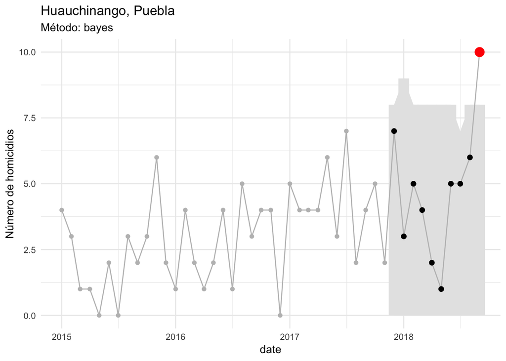

```r
monitor_huau <- monitor_bayes(huauchinango, alpha = 0.05)
graf_monitor(monitor_huau)
```

```r
monitor_huau$data %>% tail
```

```
## # A tibble: 6 x 10
## # Groups:   state_code, state, mun_code, municipio [1]
##   state_code state mun_code municipio date       population count alerta
##        <int> <chr>    <int> <chr>     <date>          <int> <dbl> <lgl>
## 1         21 PUEB…       71 HUAUCHIN… 2018-04-01     107811     2 FALSE
## 2         21 PUEB…       71 HUAUCHIN… 2018-05-01     107898     1 FALSE
## 3         21 PUEB…       71 HUAUCHIN… 2018-06-01     107986     5 FALSE
## 4         21 PUEB…       71 HUAUCHIN… 2018-07-01     108072     5 FALSE
## 5         21 PUEB…       71 HUAUCHIN… 2018-08-01     108158     6 FALSE
## 6         21 PUEB…       71 HUAUCHIN… 2018-09-01     108244    10 TRUE
## # … with 2 more variables: alerta_nivel <dbl>, metadata <chr>
```

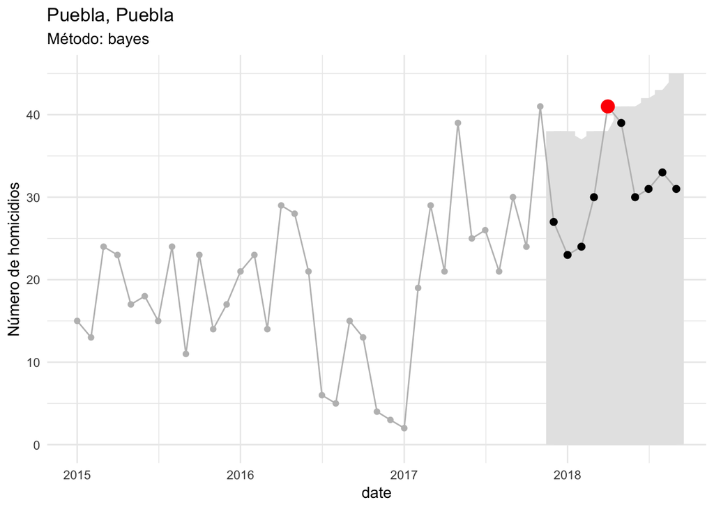

```r
monitor_pue <- monitor_bayes(puebla, alpha = 0.05)
graf_monitor(monitor_pue)
```

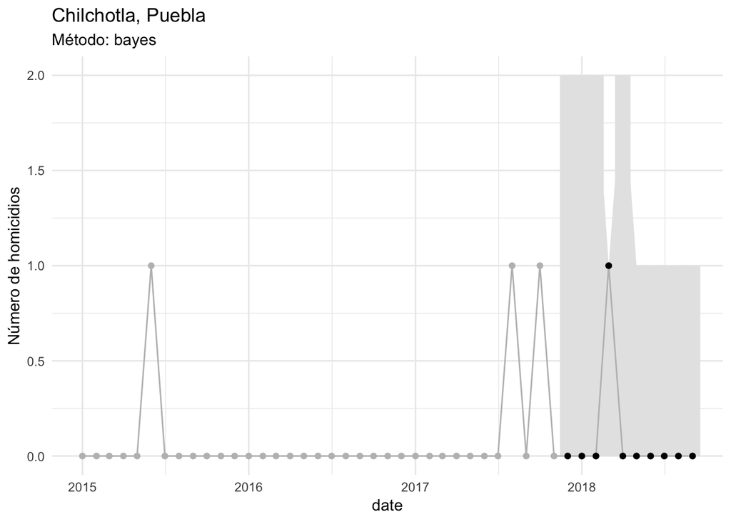

```r
monitor_chi <- monitor_bayes(chilchotla, alpha = 0.05)
graf_monitor(monitor_chi)
```

# 5 Métodos de monitoreo: Farrington

Consideramos ahora el método de Farrington (mejorado), que utiliza un modelo lineal generalizado Poisson:

1. Supongamos que los valores de referencia son $y_t$
2. Se ajusta un modelo Poisson sobredisperso a los datos de referencia, con
   $$E(y_t) = \mu_t, Var(y_t) = \phi \mu_t,$$
   donde $\phi$ es el parámetro de sobredispersión, y donde
   $$\log(\mu_k) = \alpha + \beta t$$
   sirve para modelar tendencia.
3. Se calculan pesos para los datos, reduciendo el peso de *outliers* según la distribución obtenida de los datos de referencia.
4. Se reajusta el modelo con los pesos calculados en el paso anterior
5. Para el paso de detección, usamos el método de Noufaily (2012) (ver referencia de paquete), donde la distribución de referencia para el nuevo valor $y_{t_0}$ es
   $$y_{t_0}\sim NB(\mu_{t_0}, \eta)$$
   donde $\eta= \frac{\mu_{t_0}}{\phi - 1}$.

Notas:

- Este enfoque ignora la incertidumbre en la estimación de los parámetros $\mu_{t_0}$ y $\phi$.
- Para declarar una anomalía, se requieren también al menos 5 casos en los últimos 3 meses (incluyendo el mes que se está evaluando).
6. Utilizamos 4 meses alrededor de del valor que queremos predecir, considerando dos años atrás (para un total de 2 + 2(4) + 1 = 11 datos de referencia).

### 5.0.1 Ejemplos: método de Farrington mejorado

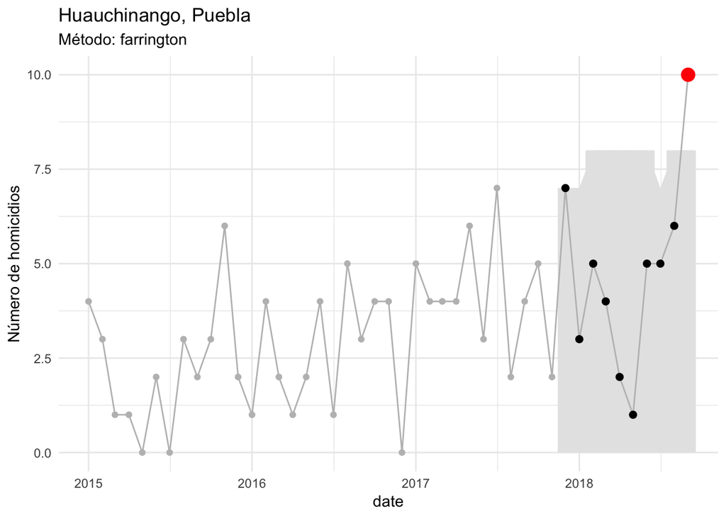

```r
monitor_huau <- monitor_farrington(huauchinango, alpha=0.05, periods = 10)
graf_monitor(monitor_huau)
```

```r
monitor_huau$data %>%  tail
```

```
## # A tibble: 6 x 10
## # Groups:   state_code, state, mun_code, municipio [1]
##   state_code state mun_code municipio date       population count alerta
##        <int> <chr>    <int> <chr>     <date>          <int> <dbl> <lgl>
## 1         21 PUEB…       71 HUAUCHIN… 2018-04-01     107811     2 FALSE
## 2         21 PUEB…       71 HUAUCHIN… 2018-05-01     107898     1 FALSE
## 3         21 PUEB…       71 HUAUCHIN… 2018-06-01     107986     5 FALSE
## 4         21 PUEB…       71 HUAUCHIN… 2018-07-01     108072     5 FALSE
## 5         21 PUEB…       71 HUAUCHIN… 2018-08-01     108158     6 FALSE
## 6         21 PUEB…       71 HUAUCHIN… 2018-09-01     108244    10 TRUE
## # … with 2 more variables: alerta_nivel <dbl>, metadata <chr>
```

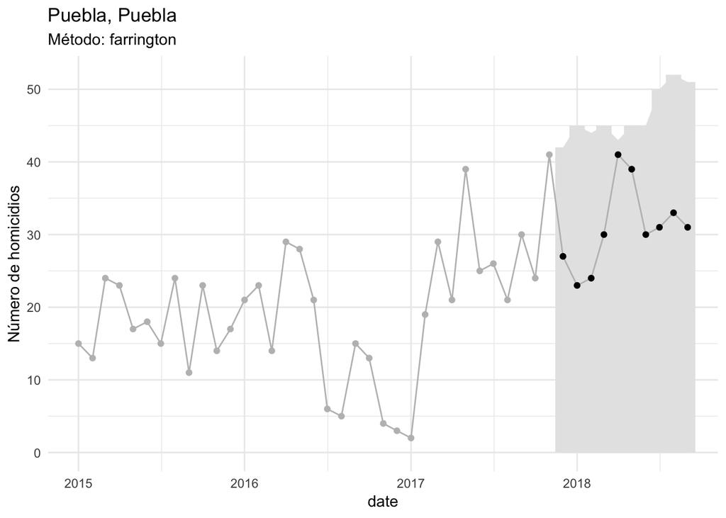

```r
monitor_pue <- monitor_farrington(puebla, alpha=0.05, periods = 10)
graf_monitor(monitor_pue)
```

```r
monitor_puebla <- monitor_farrington(puebla, periods = 10)
```

Nótese que las bandas en la estimación de Farrington puede colapsarse para municipios con niveles bajos de homicidios:

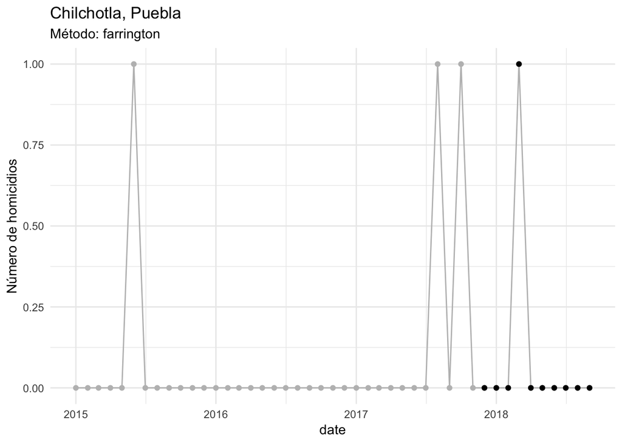

```r
monitor_chi <- monitor_farrington(chilchotla, alpha = 0.05, periods = 10)
graf_monitor(monitor_chi)
```

# 6 Otros ejemplos

En Sinaloa, por ejemplo, no observamos ninguna alarma reciente. Aún cuando algunas tasas de homicidio son muy altas en todo el periodo de referencia/evaluación, no se detectan brotes recientes:

```r
#sinaloa_edo <- filter(homicidios, state == "SINALOA")
sinaloa_edo <- readRDS("data/sinaloa.rds")
sinaloa_edo %>% group_by(municipio) %>% summarise(count = sum(count)) %>%
    arrange(desc(count))
```

```
## # A tibble: 18 x 2
##    municipio         count
##    <chr>             <dbl>
##  1 CULIACÁN           2449
##  2 MAZATLÁN            763
##  3 AHOME               544
##  4 GUASAVE             484
##  5 NAVOLATO            404
##  6 EL FUERTE           215
##  7 MOCORITO            180
##  8 SALVADOR ALVARADO   150
##  9 ROSARIO             132
## 10 CONCORDIA           128
## 11 SINALOA             127
## 12 BADIRAGUATO         115
## 13 ELOTA               106
## 14 ESCUINAPA            97
## 15 SAN IGNACIO          87
## 16 ANGOSTURA            83
## 17 CHOIX                65
## 18 COSALÁ               26
```

```r
dat_sinaloa <- sinaloa_edo %>% split(.$municipio)
monitores_sinaloa <-
    lapply(dat_sinaloa, function(df){
        monitor_mun <- monitor_farrington(df, alpha = 0.02, periods = 5)
        g <- graf_monitor(monitor_mun)
        g
    })
```

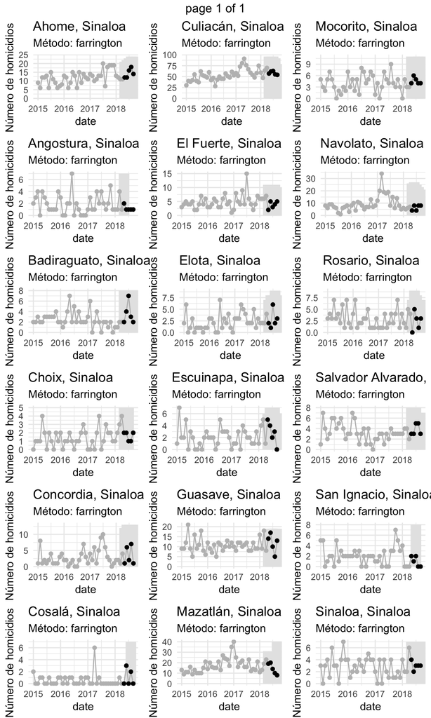

```r
library(gridExtra)
marrangeGrob(monitores_sinaloa, nrow = 6, ncol = 3)
```

En los siguientes ejemplos sólo mostramos los municipios con detección de anomalías:

```r
mex_edo <- filter(homicidios, state == "MICHOACÁN")
#sinaloa_edo <- readRDS("data/sinaloa.rds")
mex_edo %>% group_by(municipio) %>% summarise(count = sum(count)) %>%
    arrange(desc(count))
```

```
## # A tibble: 113 x 2
##    municipio       count
##    <chr>           <dbl>
##  1 MORELIA          1490
##  2 URUAPAN           639
##  3 ZAMORA            504
##  4 APATZINGÁN        471
##  5 LÁZARO CÁRDENAS   437
##  6 LA PIEDAD         266
##  7 SAHUAYO           236
##  8 MÚGICA            205
##  9 ZITÁCUARO         179
## 10 BUENAVISTA        165
## # … with 103 more rows
```

```r
dat_mex <- mex_edo %>% split(.$municipio)
monitores_mex <-
    lapply(dat_mex, function(df){
        monitor_mun <- monitor_farrington(df, alpha = 0.02, periods = 5)
        g <- graf_monitor(monitor_mun)
        list(graf = g, monitor = monitor_mun)
    })
```

```r
tiene_alerta <- function(monitor){
    any(monitor$monitor$data$alerta == 1, na.rm = TRUE)
}
monitores_alarma <- keep(monitores_mex, tiene_alerta)
```

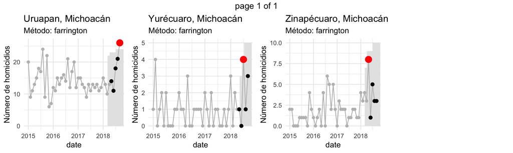

```r
graficas <- monitores_alarma %>% map(~.$graf)
marrangeGrob(graficas, nrow = 1, ncol = 4)
```

```r
mex_edo <- filter(homicidios, state == "VERACRUZ")
#sinaloa_edo <- readRDS("data/sinaloa.rds")
mex_edo %>% group_by(municipio) %>% summarise(count = sum(count)) %>%
    arrange(desc(count))
```

```
## # A tibble: 214 x 2
##    municipio            count
##    <chr>                <dbl>
##  1 VERACRUZ               471
##  2 CÓRDOBA                362
##  3 XALAPA                 326
##  4 COATZACOALCOS          320
##  5 POZA RICA DE HIDALGO   286
##  6 PAPANTLA               227
##  7 ACAYUCAN               195
##  8 PÁNUCO                 194
##  9 TUXPAN                 182
## 10 TIERRA BLANCA          177
## # … with 204 more rows
```

```r
dat_mex <- mex_edo %>% split(.$municipio)
monitores_mex <-
    lapply(dat_mex, function(df){
        monitor_mun <- monitor_farrington(df, alpha = 0.02, periods = 5)
        g <- graf_monitor(monitor_mun)
        list(graf = g, monitor = monitor_mun)
    })
```

```r
monitores_alarma <- keep(monitores_mex, tiene_alerta)
```

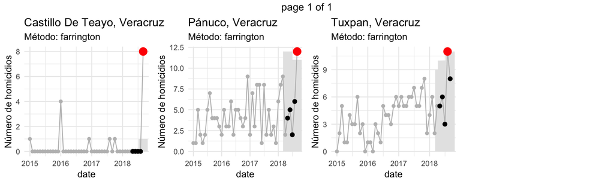

```r
graficas <- monitores_alarma %>% map(~.$graf)
marrangeGrob(graficas, nrow = 1, ncol = 4)
```

# 7 Propuesta: Método mixto

Proponemos un método mixto para construir rango y alertas para todos los municipios:

- Aplicamos primero el método Farrington flexible. Si el algoritmo converge, y hay suficientes datos (dos años atrás), utilizamos su salida.
- En otro caso, utilizamos el método bayesiano simple aplicado a los últimos 6 meses de datos.

Si hay suficientes datos hacia atrás, Farrington puede fallar cuando observamos conteos muy bajos (proporción alta de ceros).

Típicamente, estos métodos se evalúan con etiquetado de brotes según expertos en epidemiología ((Yang et al. 2018)). En nuestro caso, consideramos propiedades básicas de la estimación y comportamiento con los datos observados, pero los métodos deberán ser evaluados por expertos en el tema que puedan etiquetar cuáles saltos indican brotes de violencia o no.

## 7.1 Método mixto para todos los municipios.

Al aplicar para detección del último mes con los datos actuales obtenemos la siguiente proporción de uso de Farrington vs Bayesiano simple:

```r
dat_nal <- homicidios %>% split(list(.$municipio, .$state), drop = TRUE)
length(dat_nal)
```

```
## [1] 2469
```

```r
monitores_nal <-
    lapply(dat_nal, function(df){
        # farrington por default, a menos que haya menos de 2 años de datos
        # o no converja.
        monitor_mun <- monitor(df, alpha = 0.05, periods = 1)
        #g <- graf_monitor(monitor_mun)
        #list(graf = g, monitor = monitor_mun)
        monitor_mun
    })
tipos <- sapply(monitores_nal, function(monitor){ monitor$tipo })
table(tipos)
```

```
## tipos
##      bayes farrington
##        561       1908
```

```r
conteos_bajo <- sapply(monitores_nal, function(monitor){ sum(tail(monitor$data$count,6)) < 5})
menos_1_año <- sapply(monitores_nal, function(monitor){ length(monitor$data$count) < 24})
data_frame(conteo_bajo = conteos_bajo, menos_1_año = menos_1_año, tipo = tipos) %>%
    group_by(menos_1_año, conteo_bajo, tipo) %>% tally() %>% spread(tipo, n)
```

```
## # A tibble: 4 x 4
## # Groups:   menos_1_año, conteo_bajo [4]
##   menos_1_año conteo_bajo bayes farrington
##   <lgl>       <lgl>       <int>      <int>
## 1 FALSE       FALSE          NA        675
## 2 FALSE       TRUE           23       1233
## 3 TRUE        FALSE          14         NA
## 4 TRUE        TRUE          524         NA
```

El número de alertas generadas para este último mes, los municipios afectados:

```r
alertas <- sapply(monitores_nal, function(monitor){
    any(monitor$data$alerta, na.rm = TRUE) }
    )
table(alertas)
```

```
## alertas
## FALSE  TRUE
##  2440    29
```

```r
alertas_mun <- which(alertas)
alertas_mun
```

```
##                 MEOQUI.CHIHUAHUA                CELAYA.GUANAJUATO
##                              200                              332
##              IRAPUATO.GUANAJUATO                  LEÓN.GUANAJUATO
##                              341                              344
##               PÉNJAMO.GUANAJUATO             SALAMANCA.GUANAJUATO
##                              348                              352
##      TLAPA DE COMONFORT.GUERRERO                 EL SALTO.JALISCO
##                              445                              572
##              GUADALAJARA.JALISCO                     TALA.JALISCO
##                              577                              623
##         IXTAPAN DE LA SAL.MÉXICO         TENANGO DEL VALLE.MÉXICO
##                              705                              755
##                   TEXCOCO.MÉXICO                URUAPAN.MICHOACÁN
##                              764                              891
##                  TEMIXCO.MORELOS                  TECUALA.NAYARIT
##                              919                              951
##                GARCÍA.NUEVO LEÓN                JUÁREZ.NUEVO LEÓN
##                              971                              983
##             MONTERREY.NUEVO LEÓN SANTO DOMINGO TEHUANTEPEC.OAXACA
##                              994                             1521
##      TLALIXTAC DE CABRERA.OAXACA              HUAUCHINANGO.PUEBLA
##                             1554                             1647
##     SAN MARTÍN TEXMELUCAN.PUEBLA                    CAJEME.SONORA
##                             1707                             1916
##       CASTILLO DE TEAYO.VERACRUZ         EMILIANO ZAPATA.VERACRUZ
##                             2123                             2157
##              LA ANTIGUA.VERACRUZ                  PÁNUCO.VERACRUZ
##                             2187                             2223
##                 LORETO.ZACATECAS
##                             2435
```

Finalmente, mostramos los datos detectados para todos los municipios con alerta:

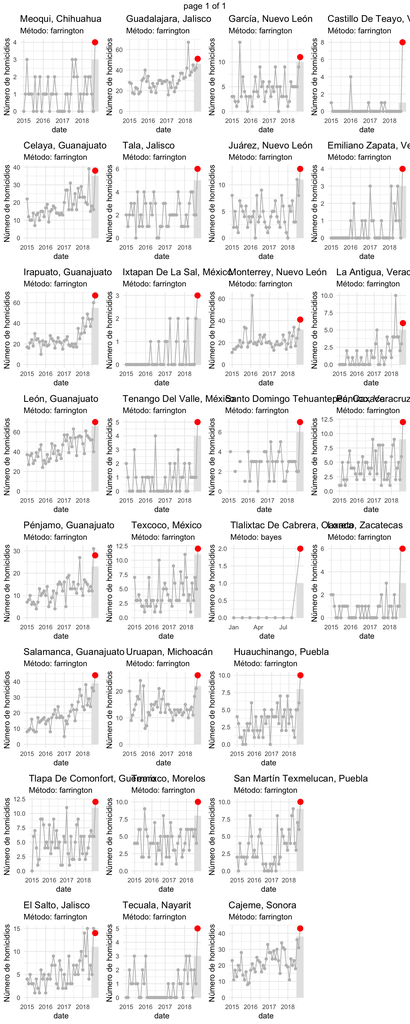

```r
monitores_alerta <- monitores_nal[alertas_mun]
graficas <- monitores_alerta %>% map(graf_monitor)
marrangeGrob(graficas, nrow = 8, ncol = 4)
```

# References

“Datos Abiertos de Incidencia Delictiva.” 2018a. https://www.gob.mx/sesnsp/acciones-y-programas/datos-abiertos-de-incidencia-delictiva?state=published.

“Datos Abiertos de Incidencia Delictiva.” 2018b. https://github.com/diegovalle/new.crimenmexico.

“Encuesta Nacional de Victimización y Percepción sobre Seguridad Pública (ENVIPE) 2018.” n.d.

Farrington, Paddy, and Nick Andrews. 2003. “Outbreak Detection: Application to Infectious Disease Surveillance.” In *Monitoring the Health of Populations: Statistical Principles and Methods for Public Health Surveillance*, edited by Ron Brookmeyer and Donna F. Stroup, 203–31. New York, NY, USA: OUP USA. http://oro.open.ac.uk/22646/.

Höhle, Michael. 2007. “Surveillance: An R Package for the Monitoring of Infectious Diseases.” *Computational Statistics* 22 (4): 571–82. https://doi.org/10.1007/s00180-007-0074-8.

Meyer, Sebastian, Leonhard Held, and Michael Höhle. 2017. “Spatio-Temporal Analysis of Epidemic Phenomena Using the R Package surveillance.” *Journal of Statistical Software* 77 (11): 1–55. https://doi.org/10.18637/jss.v077.i11.

Yang, Eunjoo, Hyun Woo Park, Yeon Hwa Choi, Jusim Kim, Lkhagvadorj Munkhdalai, Ibrahim Hussein Musa, and Keun Ho Ryu. 2018. “A Simulation-Based Study on the Comparison of Statistical and Time Series Forecasting Methods for Early Detection of Infectious Disease Outbreaks.” In *International Journal of Environmental Research and Public Health*.